# What happens on the bus? A visual data story

## Reviewing your observational logging Google form

For Project 4, I created a completely new Google Form, as my previous version for Project 2 did not fully align with the project instructions. This time, I focused on designing questions that are more observational in nature. so that it can be answered consistently over time and across different bus trips. The structure of the form allows for repeated data collection, making it possible to identify trends and patterns in passenger activity, time-of-day behaviors, and crowd levels. This improvement ensures that the data is not only relevant but also reliable for analysis and storytelling.

## Collecting more data

This google form was collected with 5 different people that are close friend of mine.

## When do people ride the bus?

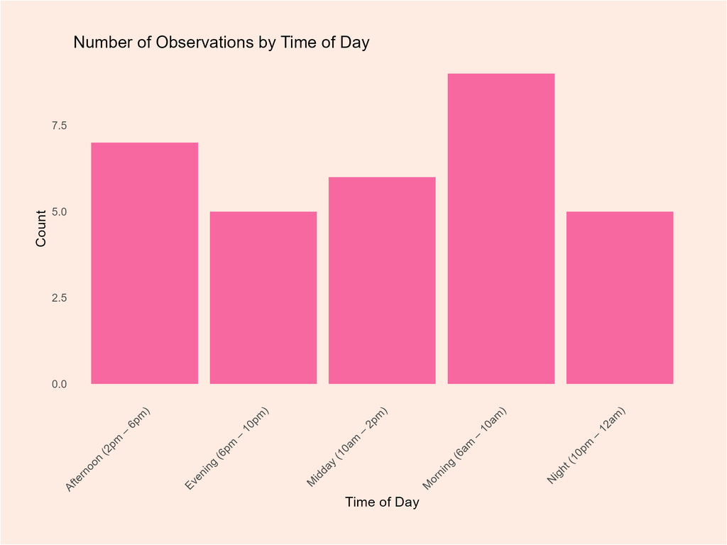

Bar chart showing the number of observations at different times of day

This bar chart shows the number of observations recorded at different times of the day. Most data was collected in the **morning** (9 observations), which likely reflects travel to school or work. The **afternoon** was the next busiest time, with 7 observations, possibly due to people returning home. Fewer observations were logged during the **evening** (5) and **night** (5), suggesting less activity or fewer responses during those times. This plot helps establish when bus activity is highest and sets the context for later visualizations. It could be interesting to compare this pattern with data from others to see whether the same time-of-day trends appear, especially when analysed alongside how busy the bus was during each period.

## What Are People Doing at Different Times of Day?

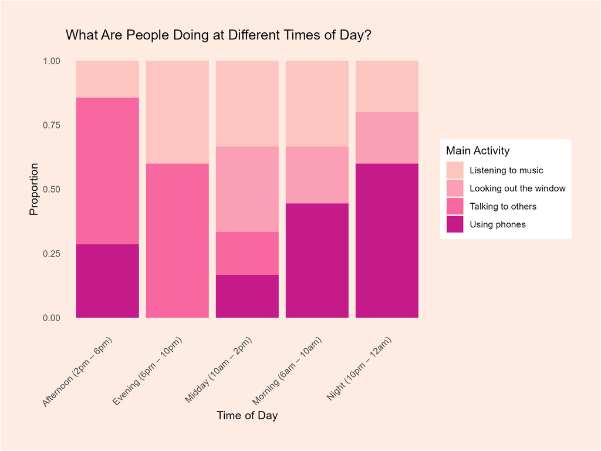

This stacked bar chart shows the proportion of observed passenger activities at different times of day. In the **morning**, the most common activity was Using phones. During the **afternoon**, passengers were mostly observed Talking to others. In the **evening**, the top activity was Talking to others.

This visual helps reveal how the activity in the bus shifts throughout the day.

## How crowded are the buses at different time of the day?

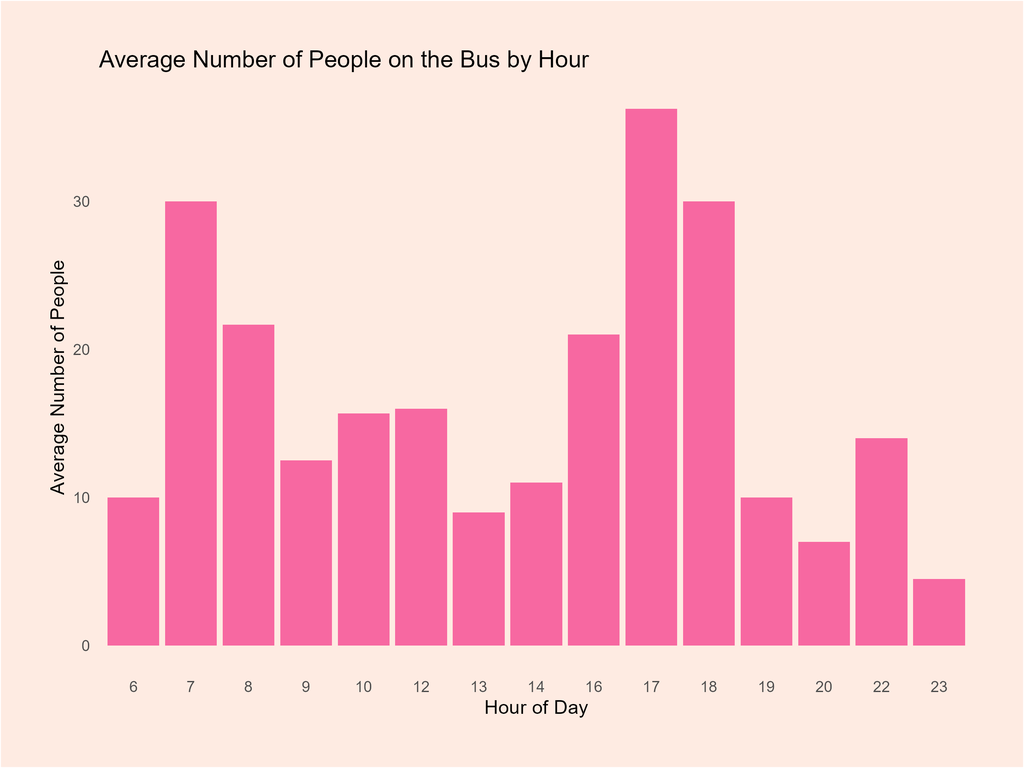

Average number of people on the bus by hour

This supports the idea that the bus is most crowded during school or work hours and end of school and work hours then it transitions and becomes less crowded.